# Advanced Visualization

## Agenda

1. Modeling Review (and upgrade)
2. Facets
3. Random cool stuff

## But first…

### Final project check-in

- **11/2:** You have a data set and have started to look at variables and some descriptive statistics
- **11/16:** You have a comprehensive set of tables and graphs that adequately describe your data and tell a “model-free” story
- **11/30:** You have finished modeling the relationships in the data and are confident in the qualitiy and validity of the results
- **12/14:** All writing is done, all tables and graphs are clear and sized correctly, report knits to a beautiful html presentation suitable for consumption by a non-technical manager

## Regression review

## Topics covered

1. Univariate linear regression
2. Hypothesis testing for proportions and continuous outcomes
3. Multiple regression
4. **Univariate regression as alternative to t-test**
5. **Categorical x categorial interactions**
6. **Multiple regresson for uplift modeling**
7. **Regression diagnostics**
8. **Categorical x continuous interactions**

## Practice: Univariate Regression for A/B

#### What is the difference in open and click rates for email A vs. email B?

Use linear regression (not proportionality tests) to answer the question.

## Solution

```r
rd <- d %>%
  filter(group!="ctrl") %>%
  mutate(email_A=(group=="email_A"))
```

Opens

```r
m <- lm(open~email_A, data = rd)
summary(m)$coef
```

```
##               Estimate  Std. Error   t value     Pr(>|t|)
## (Intercept) 0.65368143 0.002278861 286.84564 0.000000e+00
## email_ATRUE 0.06341794 0.003222797  19.67792 5.251904e-86
```

Clicks

```r
m <- lm(click~email_A, data = rd)
summary(m)$coef
```

```
##               Estimate  Std. Error  t value     Pr(>|t|)
## (Intercept) 0.08969489 0.001539421 58.26535 0.000000e+00
## email_ATRUE 0.04183503 0.002177070 19.21621 4.094966e-82
```

## Compared to proportionality test?

```r
success <- d %>%
  filter(group!="ctrl") %>%
  group_by(group,click) %>%
  count() %>%
  filter(click==1)
trials <- d %>%
  filter(group!="ctrl") %>%
  count(group)

prop.test(success$n,trials$n)
```

```
##
##  2-sample test for equality of proportions with continuity
##  correction
##
## data:  success$n out of trials$n
## X-squared = 367.2, df = 1, p-value < 2.2e-16
## alternative hypothesis: two.sided
## 95 percent confidence interval:
##  0.03754391 0.04612615
## sample estimates:
##     prop 1     prop 2
## 0.13152992 0.08969489
```

## Practice: categorical interactions

#### What is the difference in the impact that our promotional email had on purchases for those with past purchases greater than zero?

Use linear regression with a categorical by categorical interaction.

## Solution

```r
rd <- d %>%
  mutate(email=(group!="ctrl"))

m <- lm(purch~email*(past_purch>0), data = rd)
summary(m)$coef
```

```
##                               Estimate Std. Error   t value     Pr(>|t|)
## (Intercept)                  7.5569607  0.4347604 17.381898 1.361375e-67
## emailTRUE                    0.5950912  0.5308589  1.120997 2.622913e-01
## past_purch > 0TRUE           6.3940891  0.5036414 12.695718 6.585330e-37
## emailTRUE:past_purch > 0TRUE 1.1655911  0.6156093  1.893394 5.830778e-02
```

## Compare that with filter and t-test

```r
t.test(purch~email, data=filter(rd, past_purch>0))
```

```
##
##  Welch Two Sample t-test
##
## data:  purch by email
## t = -5.472, df = 67672, p-value = 4.466e-08
## alternative hypothesis: true difference in means is not equal to 0
## 95 percent confidence interval:
##  -2.391337 -1.130028
## sample estimates:
## mean in group FALSE  mean in group TRUE
##            13.95105            15.71173
```

## Visualize it (upgrade)

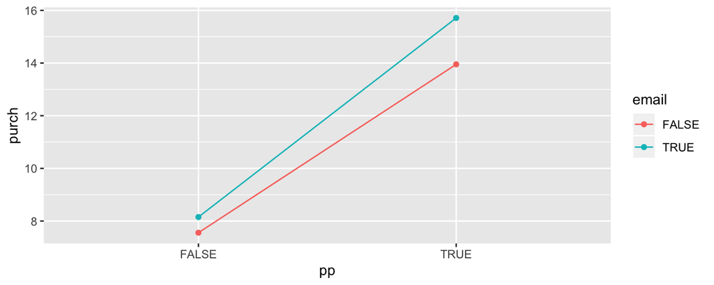

```r
rd %>%
  mutate(pp=(past_purch>0)) %>%
  group_by(email, pp) %>%
  summarise(purch = mean(purch)) %>%
  ggplot() +
  aes(x = pp, y = purch, color = email) +
  geom_line(aes(group = email)) +
  geom_point()
```

## Practice: uplift modeling

#### Given the model used in the previous practice problem, how does recieving an email change the predicted purchase amount for someone with the same baseline variables as customer 1001?

## Solution

```r
m <- lm(purch~email*(past_purch>0), data = mutate(d,email=(group!="ctrl")))
(pred <- predict(m, cbind(email=c(TRUE, FALSE), slice(d,1001))))
```

```
##        1        2
## 8.152052 7.556961
```

```r
(lift <- pred[1] - pred[2])
```

```
##         1
## 0.5950912
```

## Practice: regression diagnostics

#### Should we use a model with (past_purchase>0) as the cutoff or simply past_purch (as a continuous variable)? Split the data into test and train subsets and evaluate the models on their predictive quality.

## Solution - models and subsets

```r
# Randomly shuffle order of rows:
d_shuffled <- d %>%
  mutate(email=(group!="ctrl")) %>%
  sample_frac(size = 1, replace = FALSE)
# Split into train and test:
split <-  round(.8*nrow(d)) # 80% of dataframe
train <- d_shuffled %>%
  slice(1:split)
test <- d_shuffled %>%
  slice(split+1:nrow(d))

m1 <- lm(purch~email*(past_purch>0), data = train)
m2 <- lm(purch~email*past_purch, data = train)
```

## Solution - rmse

Model 1: past_purch > 0

```r
get_regression_points(m1, newdata = test) %>%
  mutate(sq_residuals = residual^2) %>%
  summarize(rmse = sqrt(mean(sq_residuals)))
```

```
## # A tibble: 1 x 1
##    rmse
##   <dbl>
## 1  46.0
```

Model 2: past_purch continous

```r
get_regression_points(m2, newdata = test) %>%
  mutate(sq_residuals = residual^2) %>%
  summarize(rmse = sqrt(mean(sq_residuals)))
```

```
## # A tibble: 1 x 1
##    rmse
##   <dbl>
## 1  45.5
```

## Practice: categorical by continuous interactions

```r
m <- lm(purch~email*past_purch, data = train)
summary(m)$coef
```

```
##                         Estimate   Std. Error   t value      Pr(>|t|)
## (Intercept)          7.327151549 0.2838502510 25.813440 1.915268e-146
## emailTRUE            1.017328933 0.3470672718  2.931215  3.377156e-03
## past_purch           0.026644115 0.0008063437 33.043124 3.877199e-238
## emailTRUE:past_purch 0.001277535 0.0009823222  1.300526  1.934239e-01
```

What effect does email have on the relationship between past purchases and current purchases?

## Visualising the interaction (upgrade)

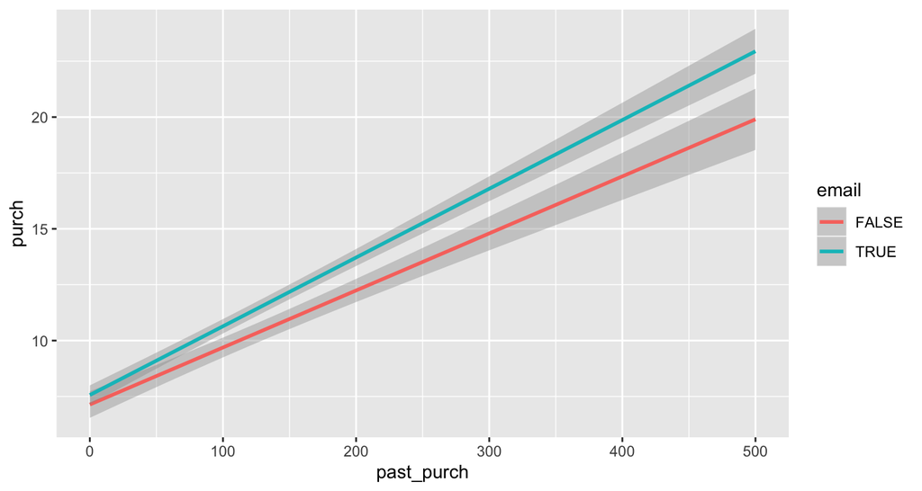

```r
train %>%
  ggplot(aes(past_purch, purch, color=email))+
  geom_smooth(method=lm)+
  xlim(0,500)
```

## Continuous by continuous interactions (upgrade)

```r
m <- lm(purch~last_purch*visits, data = train)
summary(m)$coef
```

```
##                       Estimate   Std. Error    t value      Pr(>|t|)
## (Intercept)        8.692259113 0.4520646019  19.227914  3.053635e-82
## last_purch        -0.050501612 0.0035499444 -14.226029  7.009913e-46
## visits             1.866721592 0.0684737333  27.261864 4.821991e-163
## last_purch:visits -0.003894341 0.0005399988  -7.211759  5.562577e-13
```

## Visualizing the interaction (upgrade)

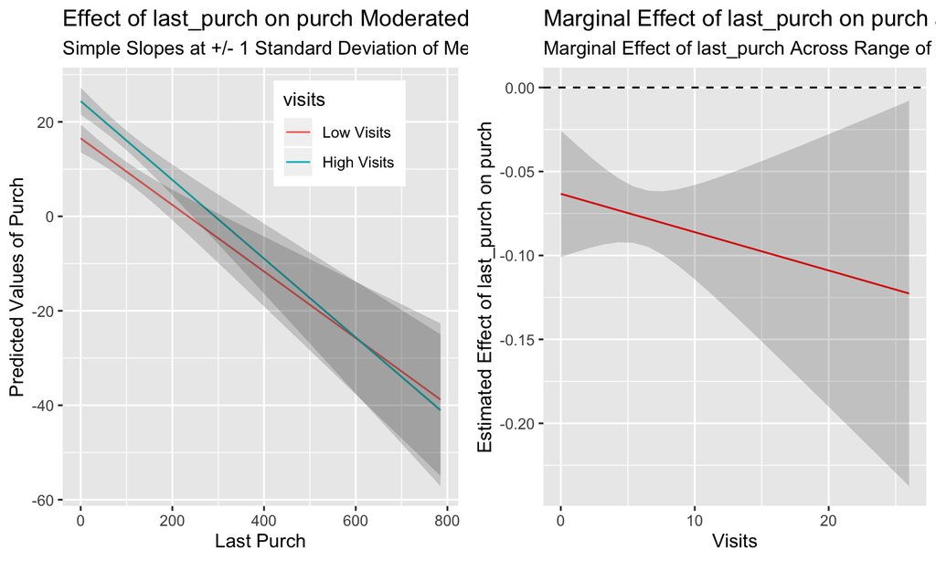

## Faceting

## Setup

```r
wine <- read_csv("../resources/winemag-data.csv") %>%
  filter(!is.na(price)) %>%
  mutate(year = as.numeric(str_extract(title,"(\\d{4})"))) %>%
  filter(province %in% c("Washington","Oregon","California")) %>%
  filter(variety %in% c("Pinot Noir", "Chardonnay", "Cabernet Sauvignon"))
```

## Facet wrap

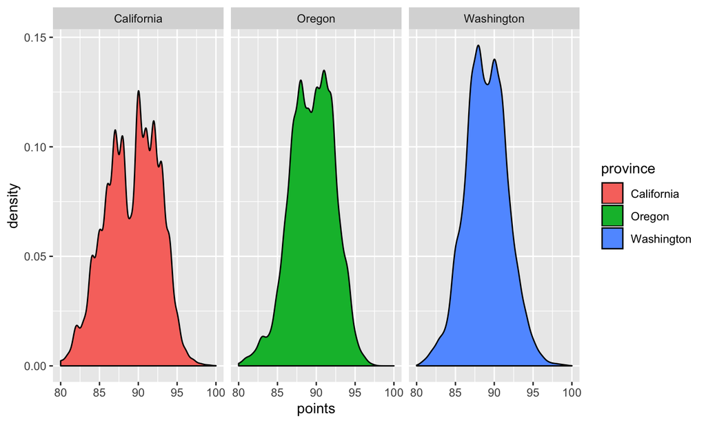

```r
wine %>%
  ggplot(aes(points, fill=province))+
  geom_density()+
  facet_wrap(facets = ~province)
```

## Facet grid

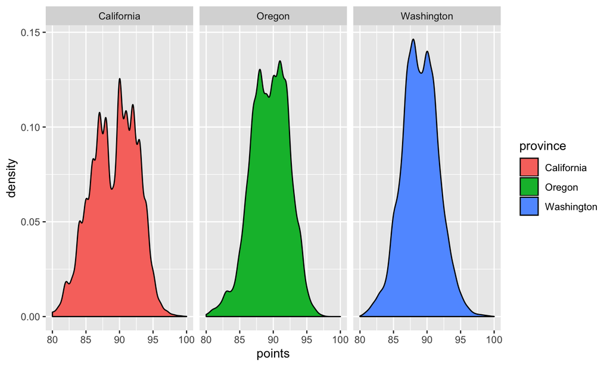

```r
wine %>%
  ggplot(aes(points, fill=province))+
  geom_density()+
  facet_grid(. ~ province)
```

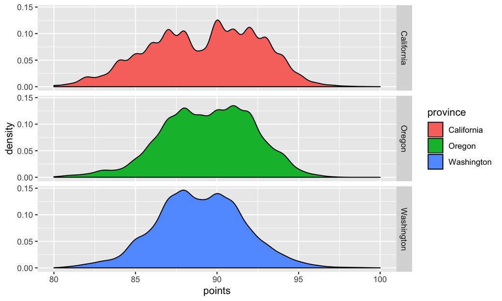

```r
wine %>%
  ggplot(aes(points, fill=province))+
  geom_density()+
  facet_grid(province ~ .)
```

## Facet grid multiple

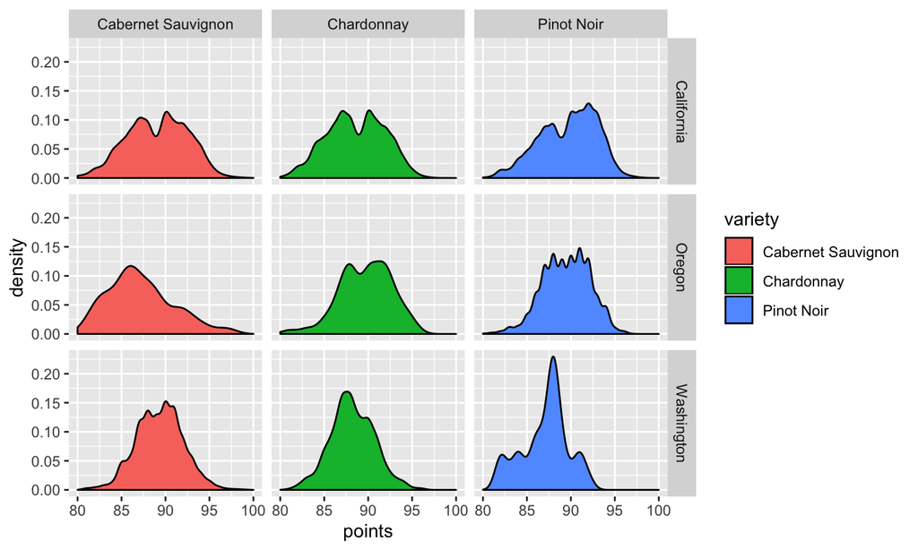

```r
wine %>%
  ggplot(aes(points, fill=variety))+
  geom_density()+
  facet_grid(province~variety)
```

## Exercise

1. Create facet grid of transparent jittered points
2. by province and variety
3. that shows log(price) as a function of points
4. with a regression line

## Solution

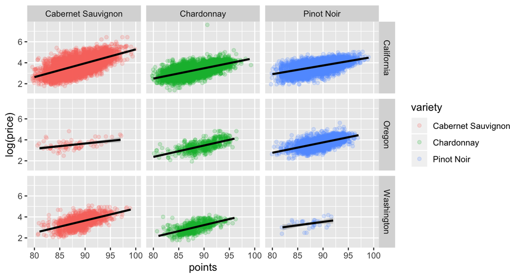

```r
wine %>%
  ggplot(aes(points,log(price), color=variety))+
  geom_jitter(alpha=0.2)+
  geom_smooth(method = "lm", color="black")+
  facet_grid(province~variety)
```

## Cowplot setup

```r
library(cowplot)
plot1 <- ggplot(wine, aes(points,log(price), color=variety))+
  geom_jitter(alpha=0.2)+
  geom_smooth(method = "lm", color="black")+
  facet_grid(province~variety)+
  theme(legend.position="none")
plot2 <- ggplot(wine, aes(points, fill=variety))+
  geom_density()+
  facet_grid(province~variety)+
  theme(legend.position="none")
```

## Cowplot plot

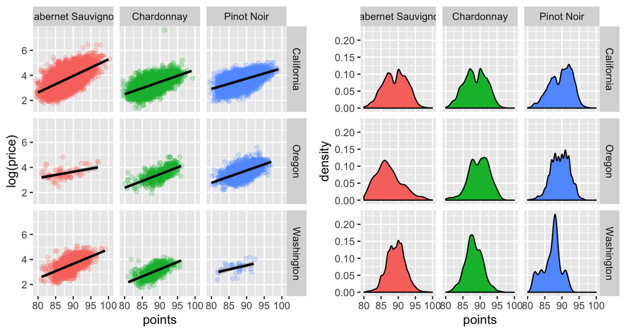

```r
plot_grid(plot1, plot2, ncol = 2, align = "h")
```

## Random cool stuff

## Custom themes

- element_text()
- element_rect()
- element_line()
- element_blank()

```r
library(wesanderson)
jameson <- function(){
  list(
    theme_minimal() +
    theme(
      text = element_text(family = "Palatino", color = "gray25"),
      plot.subtitle = element_text(size = 12),
      plot.caption = element_text(color = "gray30"),
      plot.background = element_rect(fill = "gray95"),
      plot.margin = unit(c(5, 10, 5, 10), units = "mm")
    ),
    scale_color_manual(values = wes_palette(n=5, name="Moonrise3", type = "continuous")),
    scale_fill_manual(values = wes_palette(n=5, name="Moonrise3", type = "continuous"))
  )
}
```

## Using the ‘jameson’ theme

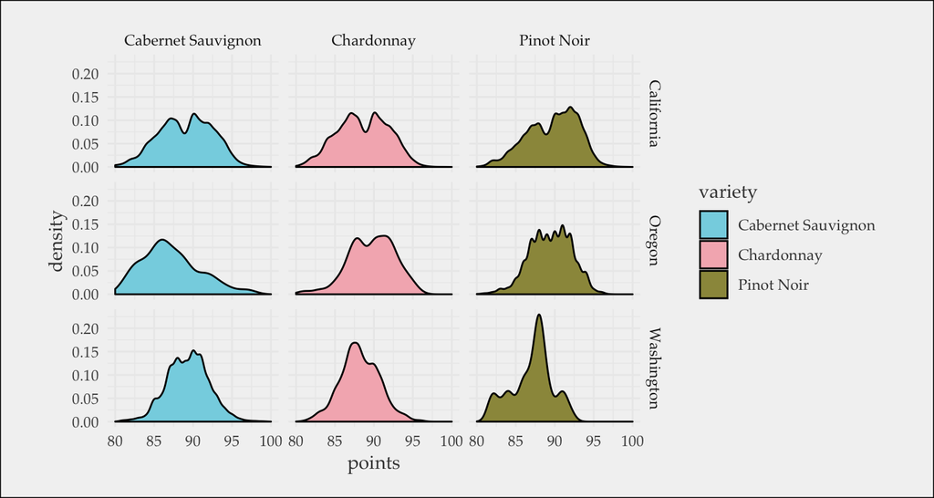

```r
wine %>%
  ggplot(aes(points, fill=variety))+
  geom_density()+
  facet_grid(province~variety)+
  jameson()
```

## Dot plot

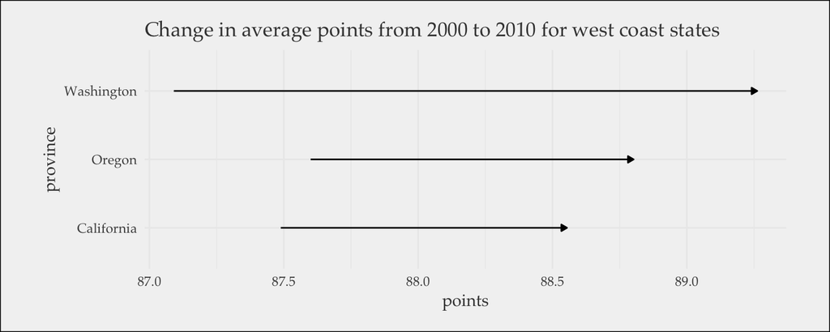

```r
wine %>%
  filter(year %in% c(2000, 2010)) %>%
  group_by(province,year) %>%
  summarise(points=mean(points)) %>%
  ggplot(aes(x = points, y = province))+
  geom_path(arrow = arrow(length = unit(1.5, "mm"), type = "closed"))+
  labs(title = "Change in average points from 2000 to 2010 for west coast states") +
  jameson()
```

## Overplotting

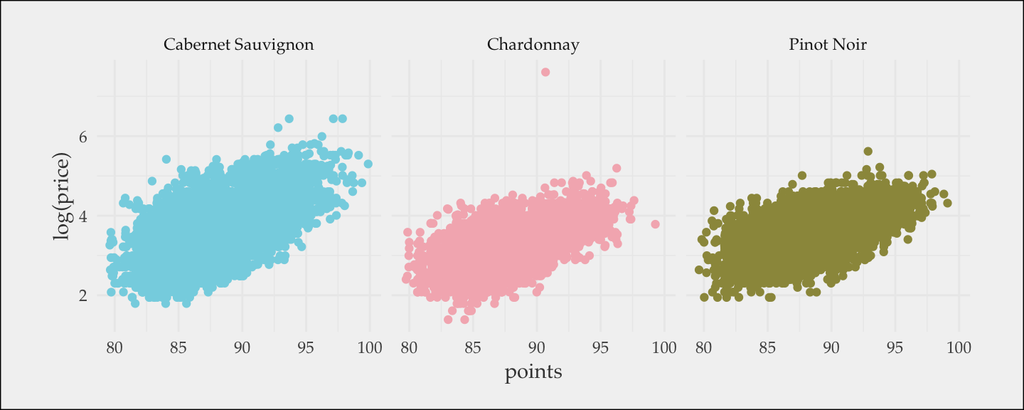

```r
wine %>%
  ggplot(aes(points, log(price), color=variety))+
  geom_jitter()+
  facet_grid(. ~ variety)+
  jameson()+
  theme(legend.position="none")
```

## 2d density

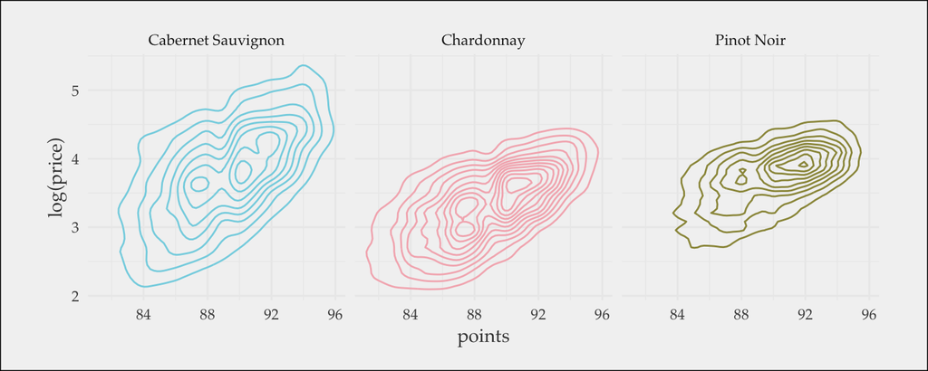

```r
wine %>%
  ggplot(aes(points, log(price), color=variety))+
  geom_density_2d()+
  facet_grid(. ~ variety)+
  jameson()+
  theme(legend.position="none")
```

## 2d Histogram

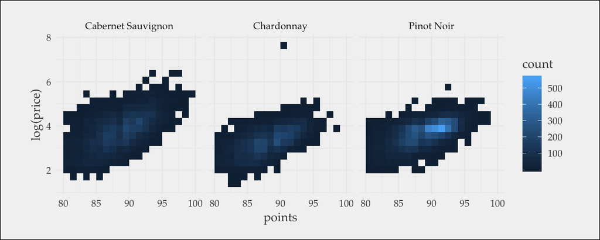

```r
wine %>%
  ggplot(aes(points,log(price)))+
  geom_bin2d(bins=20)+
  facet_grid(. ~ variety)+
  theme_minimal() +
    theme(
      text = element_text(family = "Palatino", color = "gray25"),
      plot.subtitle = element_text(size = 12),
      plot.caption = element_text(color = "gray30"),
      plot.background = element_rect(fill = "gray95"),
      plot.margin = unit(c(5, 10, 5, 10), units = "mm")
    )
```

## Long exercise

1. Gather in groups of 2-3
2. Create the ugliest custom theme that you can
3. Apply it to a plot of the wine data (you can use full dataset)
4. To show something **completely new!!!**